Скачать ipynb

# [Введение в анализ данных](https://miptstats.github.io/courses/ad_fivt.html)

## Титаник

Был крупнейшим пассажирским судном в 1912—1913 годах. Во время первого рейса затонул в северной Атлантике, столкнувшись с айсбергом в ночь с 14 на 15 апреля 1912 года, при этом погибло 1502 из 2224 пассажиров и членов экипажа.

Данные о пассажирах были собраны в таблицы, которые можно скачать с [Kaggle](https://www.kaggle.com/c/titanic/data). Эти данные часто используются в качестве обучающих в анализе данных.

[figure not shown]

**Этот обучающий ноутбук на примерах показывает основную функциональность библиотек `pandas` и `seaborn`.**

Подробные обучающие ноутбуки можно посмотреть по ссылкам:

- [Библиотека pandas — типы данных Series и DataFrame, запись и чтение файлов, работа с датами.](https://miptstats.github.io/courses/python/08_pandas1.html)
- [Библиотека pandas — объединение таблиц, группировки, таблицы сопряженности и сводные таблицы.](https://miptstats.github.io/courses/python/10_pandas2.html)
- [Библиотека seaborn.](https://miptstats.github.io/courses/python/09_seaborn.html)

```python
import numpy as np
import pandas as pd

import matplotlib.pyplot as plt
import seaborn as sns
sns.set(palette='Set2', font_scale=1.3)
```

### 1. Чтение данных

*[Подробнее про чтение и запись данных.](https://miptstats.github.io/courses/python/08_pandas1.html#3.-Чтение-и-запись-данных)*

Прочитаем данные с помощью библиотеки `pandas`. Библиотека pandas предназначена для статистической обработки данных, по функциональности близкий к SQL и R. Включает в себя функциональность работы с базами данных и таблицами Excel.

При чтении укажем, что первую колонку нужно использовать в качестве индекса (т.е. ключа) в таблице: `index_col=0`.

Мы видим таблицу со следующими колонками:

- `Pclass` — класс пассажира (`1` — высший, `2` — средний, `3` — низший);
- `Name` — имя;
- `Sex` — пол;
- `Age` — возраст;
- `SibSp` — количество братьев, сестер, сводных братьев, сводных сестер, супругов на борту титаника;
- `Parch` — количество родителей, детей (в том числе приемных) на борту титаника;
- `Ticket` — номер билета;
- `Fare` — плата за проезд;
- `Cabin` — каюта;
- `Embarked` — порт посадки (`C` — Шербур; `Q` — Квинстаун; `S` — Саутгемптон).

```python
data = pd.read_csv('train.csv', index_col=0)
data
```

| PassengerId | Survived | Pclass | Name | Sex | Age | SibSp | Parch | Ticket | Fare | Cabin | Embarked |
| --- | --- | --- | --- | --- | --- | --- | --- | --- | --- | --- | --- |
| 1 | 0 | 3 | Braund, Mr. Owen Harris | male | 22.0 | 1 | 0 | A/5 21171 | 7.2500 | NaN | S |
| 2 | 1 | 1 | Cumings, Mrs. John Bradley (Florence Briggs Th... | female | 38.0 | 1 | 0 | PC 17599 | 71.2833 | C85 | C |
| 3 | 1 | 3 | Heikkinen, Miss. Laina | female | 26.0 | 0 | 0 | STON/O2. 3101282 | 7.9250 | NaN | S |
| 4 | 1 | 1 | Futrelle, Mrs. Jacques Heath (Lily May Peel) | female | 35.0 | 1 | 0 | 113803 | 53.1000 | C123 | S |
| 5 | 0 | 3 | Allen, Mr. William Henry | male | 35.0 | 0 | 0 | 373450 | 8.0500 | NaN | S |
| ... | ... | ... | ... | ... | ... | ... | ... | ... | ... | ... | ... |
| 887 | 0 | 2 | Montvila, Rev. Juozas | male | 27.0 | 0 | 0 | 211536 | 13.0000 | NaN | S |
| 888 | 1 | 1 | Graham, Miss. Margaret Edith | female | 19.0 | 0 | 0 | 112053 | 30.0000 | B42 | S |
| 889 | 0 | 3 | Johnston, Miss. Catherine Helen "Carrie" | female | NaN | 1 | 2 | W./C. 6607 | 23.4500 | NaN | S |
| 890 | 1 | 1 | Behr, Mr. Karl Howell | male | 26.0 | 0 | 0 | 111369 | 30.0000 | C148 | C |
| 891 | 0 | 3 | Dooley, Mr. Patrick | male | 32.0 | 0 | 0 | 370376 | 7.7500 | NaN | Q |

891 rows × 11 columns

Можно вывести только строго указанное количество строк

```python
data.head(2)
```

| PassengerId | Survived | Pclass | Name | Sex | Age | SibSp | Parch | Ticket | Fare | Cabin | Embarked |
| --- | --- | --- | --- | --- | --- | --- | --- | --- | --- | --- | --- |
| 1 | 0 | 3 | Braund, Mr. Owen Harris | male | 22.0 | 1 | 0 | A/5 21171 | 7.2500 | NaN | S |
| 2 | 1 | 1 | Cumings, Mrs. John Bradley (Florence Briggs Th... | female | 38.0 | 1 | 0 | PC 17599 | 71.2833 | C85 | C |

Соответствующая переменная имеет тип данных `DataFrame`.

```python
type(data)
```

```
pandas.core.frame.DataFrame
```

### 2. Способы извлечения данных

Данные из отдельной колонки

```python
data['Name']
```

```
PassengerId
1                                Braund, Mr. Owen Harris
2      Cumings, Mrs. John Bradley (Florence Briggs Th...
3                                 Heikkinen, Miss. Laina
4           Futrelle, Mrs. Jacques Heath (Lily May Peel)
5                               Allen, Mr. William Henry
                             ...
887                                Montvila, Rev. Juozas
888                         Graham, Miss. Margaret Edith
889             Johnston, Miss. Catherine Helen "Carrie"
890                                Behr, Mr. Karl Howell
891                                  Dooley, Mr. Patrick
Name: Name, Length: 891, dtype: object
```

Если имя колонки "достаточно хорошее", то можно и так

```python
data.Name
```

```
PassengerId
1                                Braund, Mr. Owen Harris
2      Cumings, Mrs. John Bradley (Florence Briggs Th...
3                                 Heikkinen, Miss. Laina
4           Futrelle, Mrs. Jacques Heath (Lily May Peel)
5                               Allen, Mr. William Henry
                             ...
887                                Montvila, Rev. Juozas
888                         Graham, Miss. Margaret Edith
889             Johnston, Miss. Catherine Helen "Carrie"
890                                Behr, Mr. Karl Howell
891                                  Dooley, Mr. Patrick
Name: Name, Length: 891, dtype: object
```

Данные по столбцу имеют тип данных `Series`.

```python
type(data.Name)
```

```
pandas.core.series.Series
```

Можно вытащить сразу несколько колонок

```python
data[['Survived', 'Pclass', 'Name']]
```

| PassengerId | Survived | Pclass | Name |
| --- | --- | --- | --- |
| 1 | 0 | 3 | Braund, Mr. Owen Harris |
| 2 | 1 | 1 | Cumings, Mrs. John Bradley (Florence Briggs Th... |
| 3 | 1 | 3 | Heikkinen, Miss. Laina |
| 4 | 1 | 1 | Futrelle, Mrs. Jacques Heath (Lily May Peel) |
| 5 | 0 | 3 | Allen, Mr. William Henry |
| ... | ... | ... | ... |
| 887 | 0 | 2 | Montvila, Rev. Juozas |
| 888 | 1 | 1 | Graham, Miss. Margaret Edith |
| 889 | 0 | 3 | Johnston, Miss. Catherine Helen "Carrie" |
| 890 | 1 | 1 | Behr, Mr. Karl Howell |
| 891 | 0 | 3 | Dooley, Mr. Patrick |

891 rows × 3 columns

Имена всех колонок

```python
data.columns
```

```
Index(['Survived', 'Pclass', 'Name', 'Sex', 'Age', 'SibSp', 'Parch', 'Ticket',
       'Fare', 'Cabin', 'Embarked'],
      dtype='object')
```

Список всех индексов таблицы (т.е. ключей)

```python
data.index
```

```
Int64Index([  1,   2,   3,   4,   5,   6,   7,   8,   9,  10,
            ...
            882, 883, 884, 885, 886, 887, 888, 889, 890, 891],
           dtype='int64', name='PassengerId', length=891)
```

Название колонки-индекса

```python
data.index.name
```

[output not shown]

Тип данных в каждой из колонок таблицы

```python
data.dtypes
```

```
Survived      int64
Pclass        int64
Name         object
Sex          object
Age         float64
SibSp         int64
Parch         int64
Ticket       object
Fare        float64
Cabin        object
Embarked     object
dtype: object
```

Строку таблицы, соответствующую *ключу 1*, можно получить через `loc`

```python
data.loc[1]
```

```
Survived                          0
Pclass                            3
Name        Braund, Mr. Owen Harris
Sex                            male
Age                              22
SibSp                             1
Parch                             0
Ticket                    A/5 21171
Fare                           7.25
Cabin                           NaN
Embarked                          S
Name: 1, dtype: object
```

Обратите внимание, что *обычный численный индекс* этой строки равен 0. По нему также можно извлекать строку с мопощью `iloc`.

```python
data.iloc[0]
```

```
Survived                          0
Pclass                            3
Name        Braund, Mr. Owen Harris
Sex                            male
Age                              22
SibSp                             1
Parch                             0
Ticket                    A/5 21171
Fare                           7.25
Cabin                           NaN
Embarked                          S
Name: 1, dtype: object
```

Если же попробовать запустить

data.loc[0]

то возникнет исключение `KeyError: 0`, поскольку ключа `0` в этой таблице нет.

Можно извлечь несколько строк

```python
data.iloc[0:3]
```

| PassengerId | Survived | Pclass | Name | Sex | Age | SibSp | Parch | Ticket | Fare | Cabin | Embarked |
| --- | --- | --- | --- | --- | --- | --- | --- | --- | --- | --- | --- |
| 1 | 0 | 3 | Braund, Mr. Owen Harris | male | 22.0 | 1 | 0 | A/5 21171 | 7.2500 | NaN | S |
| 2 | 1 | 1 | Cumings, Mrs. John Bradley (Florence Briggs Th... | female | 38.0 | 1 | 0 | PC 17599 | 71.2833 | C85 | C |
| 3 | 1 | 3 | Heikkinen, Miss. Laina | female | 26.0 | 0 | 0 | STON/O2. 3101282 | 7.9250 | NaN | S |

Можно извлечь конкретное значение

```python
data.iloc[0]['Name']
```

```
'Braund, Mr. Owen Harris'
```

Или так

```python
data.iloc[0, 2]
```

```
'Braund, Mr. Owen Harris'
```

### 3. Примеры анализа данных из таблицы

#### 3.1 Простые операции из `pandas`

Все описательные статистики по каждой колонке с вещественным типом данных

```python
data.describe()
```

|  | Survived | Pclass | Age | SibSp | Parch | Fare |
| --- | --- | --- | --- | --- | --- | --- |
| count | 891.000000 | 891.000000 | 714.000000 | 891.000000 | 891.000000 | 891.000000 |
| mean | 0.383838 | 2.308642 | 29.699118 | 0.523008 | 0.381594 | 32.204208 |
| std | 0.486592 | 0.836071 | 14.526497 | 1.102743 | 0.806057 | 49.693429 |
| min | 0.000000 | 1.000000 | 0.420000 | 0.000000 | 0.000000 | 0.000000 |
| 25% | 0.000000 | 2.000000 | 20.125000 | 0.000000 | 0.000000 | 7.910400 |
| 50% | 0.000000 | 3.000000 | 28.000000 | 0.000000 | 0.000000 | 14.454200 |
| 75% | 1.000000 | 3.000000 | 38.000000 | 1.000000 | 0.000000 | 31.000000 |
| max | 1.000000 | 3.000000 | 80.000000 | 8.000000 | 6.000000 | 512.329200 |

Идентификация пропусков в таблице

```python
data.isna()
```

| PassengerId | Survived | Pclass | Name | Sex | Age | SibSp | Parch | Ticket | Fare | Cabin | Embarked |
| --- | --- | --- | --- | --- | --- | --- | --- | --- | --- | --- | --- |
| 1 | False | False | False | False | False | False | False | False | False | True | False |
| 2 | False | False | False | False | False | False | False | False | False | False | False |
| 3 | False | False | False | False | False | False | False | False | False | True | False |
| 4 | False | False | False | False | False | False | False | False | False | False | False |
| 5 | False | False | False | False | False | False | False | False | False | True | False |
| ... | ... | ... | ... | ... | ... | ... | ... | ... | ... | ... | ... |
| 887 | False | False | False | False | False | False | False | False | False | True | False |
| 888 | False | False | False | False | False | False | False | False | False | False | False |
| 889 | False | False | False | False | True | False | False | False | False | True | False |
| 890 | False | False | False | False | False | False | False | False | False | False | False |
| 891 | False | False | False | False | False | False | False | False | False | True | False |

891 rows × 11 columns

Можно посчитать долю пропущенных значений в каждой колонке

```python
data.isna().mean()
```

```
Survived    0.000000
Pclass      0.000000
Name        0.000000
Sex         0.000000
Age         0.198653
SibSp       0.000000
Parch       0.000000
Ticket      0.000000
Fare        0.000000
Cabin       0.771044
Embarked    0.002245
dtype: float64
```

Сортировка по столбцу

```python
data.sort_values(by='Age')
```

| PassengerId | Survived | Pclass | Name | Sex | Age | SibSp | Parch | Ticket | Fare | Cabin | Embarked |
| --- | --- | --- | --- | --- | --- | --- | --- | --- | --- | --- | --- |
| 804 | 1 | 3 | Thomas, Master. Assad Alexander | male | 0.42 | 0 | 1 | 2625 | 8.5167 | NaN | C |
| 756 | 1 | 2 | Hamalainen, Master. Viljo | male | 0.67 | 1 | 1 | 250649 | 14.5000 | NaN | S |
| 645 | 1 | 3 | Baclini, Miss. Eugenie | female | 0.75 | 2 | 1 | 2666 | 19.2583 | NaN | C |
| 470 | 1 | 3 | Baclini, Miss. Helene Barbara | female | 0.75 | 2 | 1 | 2666 | 19.2583 | NaN | C |
| 79 | 1 | 2 | Caldwell, Master. Alden Gates | male | 0.83 | 0 | 2 | 248738 | 29.0000 | NaN | S |
| ... | ... | ... | ... | ... | ... | ... | ... | ... | ... | ... | ... |
| 860 | 0 | 3 | Razi, Mr. Raihed | male | NaN | 0 | 0 | 2629 | 7.2292 | NaN | C |
| 864 | 0 | 3 | Sage, Miss. Dorothy Edith "Dolly" | female | NaN | 8 | 2 | CA. 2343 | 69.5500 | NaN | S |
| 869 | 0 | 3 | van Melkebeke, Mr. Philemon | male | NaN | 0 | 0 | 345777 | 9.5000 | NaN | S |
| 879 | 0 | 3 | Laleff, Mr. Kristo | male | NaN | 0 | 0 | 349217 | 7.8958 | NaN | S |
| 889 | 0 | 3 | Johnston, Miss. Catherine Helen "Carrie" | female | NaN | 1 | 2 | W./C. 6607 | 23.4500 | NaN | S |

891 rows × 11 columns

#### 3.2 Графики с помощью `seaborn`

Посмотрим, как можно работать с библиотекой `seaborn`. Это популярная библиотека готовых шаблонов для статистической визуализации, написанная на бэкенде `matplotlib`. Она имеет высокоуровневый интерфейс и по умолчанию может строить более эстетичные графики.

Построим гистограмму по возрасту отдельно для мужчин и женщин.

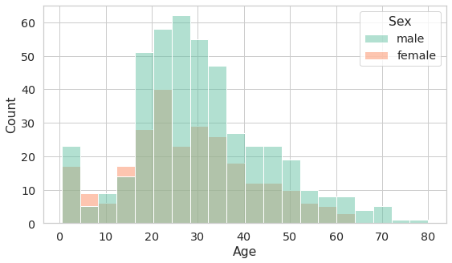

```python
with sns.axes_style('whitegrid'):
    plt.figure(figsize=(9, 5))
    sns.histplot(data=data, x='Age', hue='Sex')
```

Построим боксплоты (ящики с усами) для стоимости билета в зависимости от класса.

*[Подробнее про боксплоты.](https://miptstats.github.io/courses/python/09_seaborn.html#4.-Box-plot)*

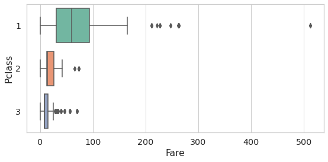

```python
with sns.axes_style('whitegrid'):
    plt.figure(figsize=(9, 4))
    sns.boxplot(data=data, x='Fare', y='Pclass', orient='h')
```

Ограничим значения по горизонтальной оси

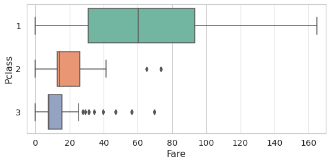

```python
with sns.axes_style('whitegrid'):
    plt.figure(figsize=(9, 4))
    sns.boxplot(data=data, x='Fare', y='Pclass', orient='h')
    plt.xlim((-5, 170))
```

#### 3.3 Более сложные операции из `pandas`

*[Подробнее про группировку данных.](https://miptstats.github.io/courses/python/10_pandas2.html)*

Сгруппируем данные по классу и усредним по всем численным колонкам

```python
data.groupby(by='Pclass').mean()
```

| Pclass | Survived | Age | SibSp | Parch | Fare |
| --- | --- | --- | --- | --- | --- |
| 1 | 0.629630 | 38.233441 | 0.416667 | 0.356481 | 84.154687 |
| 2 | 0.472826 | 29.877630 | 0.402174 | 0.380435 | 20.662183 |
| 3 | 0.242363 | 25.140620 | 0.615071 | 0.393075 | 13.675550 |

Похожим образом можно для каждого класса посчитать функции минимума и максимума

```python
data.groupby(by='Pclass').aggregate([min, max])
```

| Pclass | Survived min | Survived max | Name min | Name max | Sex min | Sex max | Age min | Age max | SibSp min | SibSp max | Parch min | Parch max | Ticket min | Ticket max | Fare min | Fare max |
| --- | --- | --- | --- | --- | --- | --- | --- | --- | --- | --- | --- | --- | --- | --- | --- | --- |
| 1 | 0 | 1 | Allen, Miss. Elisabeth Walton | Young, Miss. Marie Grice | female | male | 0.92 | 80.0 | 0 | 3 | 0 | 4 | 110152 | WE/P 5735 | 0.0 | 512.3292 |
| 2 | 0 | 1 | Abelson, Mr. Samuel | del Carlo, Mr. Sebastiano | female | male | 0.67 | 70.0 | 0 | 3 | 0 | 3 | 11668 | W/C 14208 | 0.0 | 73.5000 |
| 3 | 0 | 1 | Abbing, Mr. Anthony | van Melkebeke, Mr. Philemon | female | male | 0.42 | 74.0 | 0 | 8 | 0 | 6 | 12460 | W./C. 6609 | 0.0 | 69.5500 |

*Подробнее про агрегирующие функции.*

С помощью функции `crosstab` можно очень легко получить информацию о том, сколько человек определенного пола ехали в таком-то классе, а также сумму по строкам и столбцам.

```python
pd.crosstab(data['Sex'], data['Pclass'], margins=True)
```

| Pclass Sex | 1 | 2 | 3 | All |
| --- | --- | --- | --- | --- |
| female | 94 | 76 | 144 | 314 |
| male | 122 | 108 | 347 | 577 |
| All | 216 | 184 | 491 | 891 |

А с помощью похожей функции `pivot_table` можно легко получить информацию о том, каков максимальный возраст среди пассажиров определенного пола для каждого класса.

```python
pd.pivot_table(
    data,
    values='Age',
    index='Sex',
    columns='Pclass',
    aggfunc=np.max
)
```

| Pclass Sex | 1 | 2 | 3 |
| --- | --- | --- | --- |
| female | 63.0 | 57.0 | 63.0 |
| male | 80.0 | 70.0 | 74.0 |

Почитайте также про *[операции объединения таблиц](https://miptstats.github.io/courses/python/10_pandas2.html#2.-Объединение-таблиц)*, например, `merge` и `join`.